# Lending Club Loan Data Descriptive Analysis

Ergin Sarikaya

June 11, 2016

# PURPOSE

Goal of this paper is to understand the underlying details of the data that has been retrieved from https://www.lendingclub.com/info/download-data.action. The ultimate purpose is to use these learnings to create a Shiny web application that can enable two things:

1. A tool that can examine a certain customer’s final loan payment status
2. A tool that can illustrate the health of the ongoing loans

# DATA STRUCTURE

In this part, the published open dataset will be analyzed after scraping it from the relevant webpage. The key aim is to see what kind of data is stored in the columns and how clean the data is.

There exists 111 variables. Some of which are no use for further study and some of them have not enough data or do not have enough unique values (>1). These columns are taken out of the data set so that a clearer summary and analysis of the data can be made.

```
## [1] "These columns have more than 75% not available data:"
```

```
##  [1] "mths_since_last_record"      "mths_since_last_major_derog"
##  [3] "annual_inc_joint"            "dti_joint"
##  [5] "verification_status_joint"   "open_acc_6m"
##  [7] "open_il_6m"                  "open_il_12m"
##  [9] "open_il_24m"                 "mths_since_rcnt_il"
## [11] "total_bal_il"                "il_util"
## [13] "open_rv_12m"                 "open_rv_24m"
## [15] "max_bal_bc"                  "all_util"
## [17] "inq_fi"                      "total_cu_tl"
## [19] "inq_last_12m"                "mths_since_recent_bc_dlq"
```

```
## [1] "These columns have not enough variation:"
```

```
##  [1] "pymnt_plan"                 "out_prncp"
##  [3] "out_prncp_inv"              "total_rec_late_fee"
##  [5] "recoveries"                 "collection_recovery_fee"
##  [7] "collections_12_mths_ex_med" "policy_code"
##  [9] "application_type"           "verification_status_joint"
## [11] "acc_now_delinq"             "tot_coll_amt"
## [13] "total_bal_il"               "chargeoff_within_12_mths"
## [15] "delinq_amnt"                "num_tl_120dpd_2m"
## [17] "num_tl_30dpd"               "num_tl_90g_dpd_24m"
## [19] "pct_tl_nvr_dlq"             "tax_liens"
```

```
## [1] "The full list of columns that are taken our of the data"
```

```
##  [1] "mths_since_last_record"      "mths_since_last_major_derog"
##  [3] "annual_inc_joint"            "dti_joint"
##  [5] "verification_status_joint"   "open_acc_6m"
##  [7] "open_il_6m"                  "open_il_12m"
##  [9] "open_il_24m"                 "mths_since_rcnt_il"
## [11] "total_bal_il"                "il_util"
## [13] "open_rv_12m"                 "open_rv_24m"
## [15] "max_bal_bc"                  "all_util"
## [17] "inq_fi"                      "total_cu_tl"
## [19] "inq_last_12m"                "mths_since_recent_bc_dlq"
## [21] "pymnt_plan"                  "out_prncp"
## [23] "out_prncp_inv"               "total_rec_late_fee"
## [25] "recoveries"                  "collection_recovery_fee"
## [27] "collections_12_mths_ex_med"  "policy_code"
## [29] "application_type"            "acc_now_delinq"
## [31] "tot_coll_amt"                "chargeoff_within_12_mths"
## [33] "delinq_amnt"                 "num_tl_120dpd_2m"
## [35] "num_tl_30dpd"                "num_tl_90g_dpd_24m"
## [37] "pct_tl_nvr_dlq"              "tax_liens"
```

The general structure of the data is as follows:

```r
 str(finaldataset)
```

```
## 'data.frame':    345356 obs. of  73 variables:
##  $ id                            : chr  "1077501" "1077430" "1077175" "1076863" ...
##  $ member_id                     : int  1296599 1314167 1313524 1277178 1311441 1304742 1288686 1306957 1306721 1305201 ...
##  $ loan_amnt                     : int  5000 2500 2400 10000 5000 7000 3000 5600 5375 6500 ...
##  $ funded_amnt                   : int  5000 2500 2400 10000 5000 7000 3000 5600 5375 6500 ...
##  $ funded_amnt_inv               : num  4975 2500 2400 10000 5000 ...
##  $ term                          : chr  " 36 months" " 60 months" " 36 months" " 36 months" ...
##  $ int_rate                      : chr  " 10.65%" " 15.27%" " 15.96%" " 13.49%" ...
##  $ installment                   : num  162.9 59.8 84.3 339.3 156.5 ...
##  $ grade                         : chr  "B" "C" "C" "C" ...
##  $ sub_grade                     : chr  "B2" "C4" "C5" "C1" ...
##  $ emp_title                     : chr  "" "Ryder" "" "AIR RESOURCES BOARD" ...
##  $ emp_length                    : chr  "10+ years" "< 1 year" "10+ years" "10+ years" ...
##  $ home_ownership                : chr  "RENT" "RENT" "RENT" "RENT" ...
##  $ annual_inc                    : num  24000 30000 12252 49200 36000 ...
```

[output cut: 59 more lines]

```r
 summary(finaldataset)
```

```
##       id              member_id          loan_amnt      funded_amnt
##  Length:345356      Min.   :   70699   Min.   :  500   Min.   :  500
##  Class :character   1st Qu.: 2697058   1st Qu.: 7750   1st Qu.: 7750
##  Mode  :character   Median :10439658   Median :12000   Median :12000
##                     Mean   :18783863   Mean   :13908   Mean   :13878
##                     3rd Qu.:31257498   3rd Qu.:19200   3rd Qu.:19200
##                     Max.   :73518208   Max.   :35000   Max.   :35000
##
##  funded_amnt_inv     term             int_rate          installment
##  Min.   :    0   Length:345356      Length:345356      Min.   :  15.69
##  1st Qu.: 7500   Class :character   Class :character   1st Qu.: 248.33
##  Median :12000   Mode  :character   Mode  :character   Median : 372.71
##  Mean   :13807                                         Mean   : 426.73
##  3rd Qu.:19075                                         3rd Qu.: 559.44
##  Max.   :35000                                         Max.   :1424.57
##
##     grade            sub_grade          emp_title
##  Length:345356      Length:345356      Length:345356
##  Class :character   Class :character   Class :character
##  Mode  :character   Mode  :character   Mode  :character
##
##
##
##
##   emp_length        home_ownership       annual_inc
##  Length:345356      Length:345356      Min.   :      0
##  Class :character   Class :character   1st Qu.:  45000
##  Mode  :character   Mode  :character   Median :  62300
##                                        Mean   :  73176
##                                        3rd Qu.:  88000
##                                        Max.   :8900060
##
##  verification_status   issue_d          loan_status
##  Length:345356       Length:345356      Length:345356
##  Class :character    Class :character   Class :character
##  Mode  :character    Mode  :character   Mode  :character
##
##
##
##
```

[output cut: 113 more lines]

```
##  Min.   :0.0000       Min.   :      0   Min.   :      0   Min.   :     0
##  1st Qu.:0.0000       1st Qu.:  46335   1st Qu.:  19870   1st Qu.:  7100
##  Median :0.0000       Median : 106836   Median :  35042   Median : 13800
##  Mean   :0.1123       Mean   : 166591   Mean   :  46038   Mean   : 19696
##  3rd Qu.:0.0000       3rd Qu.: 242658   3rd Qu.:  58004   3rd Qu.: 25600
##  Max.   :8.0000       Max.   :9999999   Max.   :1924200   Max.   :684000
##  NA's   :697          NA's   :64996     NA's   :45783     NA's   :45783
##  total_il_high_credit_limit
##  Min.   :      0
##  1st Qu.:  12764
##  Median :  28954
##  Mean   :  38277
##  3rd Qu.:  51736
##  Max.   :2101913
##  NA's   :64996
```

Now there are 73 more meaningful columns left to examine. Let’s examine the levels we observe for **loan_status** variable.

```
##        Charged Off            Default         Fully Paid
##              60155                306             263522
##    In Grace Period  Late (16-30 days) Late (31-120 days)
##               6204               2890              12279
```

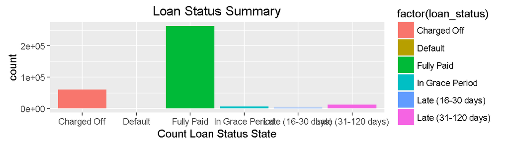

# DESCRIPTIVE ANALYSIS

In general one expects to see relationship between Loan status vs. Loan Amount, Credit Grade, Interest Rate, Annual Income, Total credit balance utilization and purpose. Let’s examine these potential relationships one by one.

## 1. Loan Status versus Loan Amount:

There can be a relationship between loan amount and Loan Status. During this process let’s first separate the loan status as risky credits and healthy credits and plot it to see if there is a risk trend through higher loan amounts.

```
## Source: local data frame [7 x 5]
## Groups: loan_amnt [7]
##
##   loan_amnt credit_health occ_count total percentage
##      <fctr>        <fctr>     <int> <int>      <dbl>
## 1      5000  Risky Credit      8840 45732   19.33001
## 2     10000  Risky Credit     20568 99953   20.57767
## 3     15000  Risky Credit     18145 76843   23.61308
## 4     20000  Risky Credit     14809 55254   26.80168
## 5     25000  Risky Credit      9064 33345   27.18249
## 6     30000  Risky Credit      5267 17602   29.92274
## 7     35000  Risky Credit      5141 16627   30.91959
```

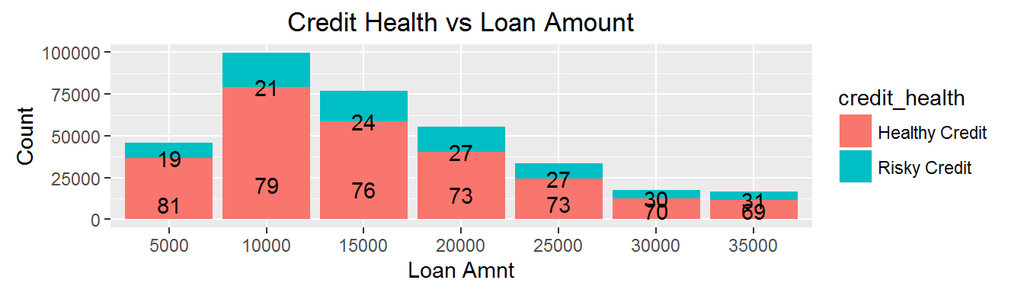

## 2. Loan Status versus Annual Income:

There can also be a relationship between annual income and Loan Status. Let’s examine this via looking at below given graph.

```
## Source: local data frame [26 x 5]
## Groups: annual_inc [26]
##
##    annual_inc credit_health occ_count total percentage
##        (fctr)        (fctr)     (int) (int)      (dbl)
## 1       10000  Risky Credit        87   310   28.06452
## 2       20000  Risky Credit      1536  4993   30.76307
## 3       30000  Risky Credit      6180 20977   29.46084
## 4       40000  Risky Credit     11391 40642   28.02766
## 5       50000  Risky Credit     13316 51049   26.08474
## 6       60000  Risky Credit     12217 49062   24.90115
## 7       70000  Risky Credit      9365 40068   23.37277
## 8       80000  Risky Credit      7574 34484   21.96381
## 9       90000  Risky Credit      5310 25803   20.57900
## 10      1e+05  Risky Credit      4198 20942   20.04584
## ..        ...           ...       ...   ...        ...
```

[figure not shown]

From the graph, we can have the conclusion that annual income **may** have an impact on the final loan status. As the income increases, the tendency to have a risky credit seems to get lower.

## 3. Loan Status versus Grade

As a third look, the relationship between credit health and credit grade is checked via below given plot.

```
## Source: local data frame [7 x 5]
## Groups: grade [7]
##
##    grade credit_health occ_count  total percentage
##   (fctr)        (fctr)     (int)  (int)      (dbl)
## 1      A  Risky Credit      4324  54025   8.003702
## 2      B  Risky Credit     15756 100086  15.742461
## 3      C  Risky Credit     23547  91340  25.779505
## 4      D  Risky Credit     19322  57374  33.677275
## 5      E  Risky Credit     12134  28553  42.496410
## 6      F  Risky Credit      5263  11098  47.422959
## 7      G  Risky Credit      1488   2880  51.666667
```

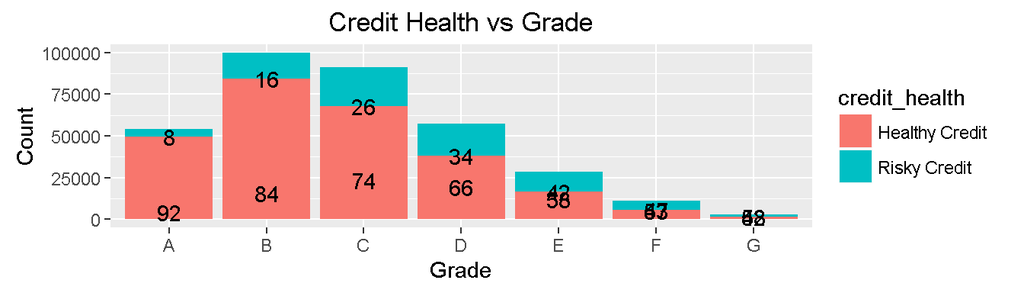

It seems that there is a level of relation between grade and credit riskiness. It may be useful to check subgrades and their impacts for more detail.

## 4. Loan Status versus Sub-Grade

Let’s see if the relationship between credit health and credit sub-grade is stronger.

```
## Source: local data frame [35 x 5]
## Groups: sub_grade [35]
##
##    sub_grade credit_health occ_count total percentage
##       (fctr)        (fctr)     (int) (int)      (dbl)
## 1         A1  Risky Credit       284  7563   3.755124
## 2         A2  Risky Credit       464  7905   5.869703
## 3         A3  Risky Credit       646  9007   7.172199
## 4         A4  Risky Credit      1192 13750   8.669091
## 5         A5  Risky Credit      1738 15800  11.000000
## 6         B1  Risky Credit      2012 15915  12.642161
## 7         B2  Risky Credit      2636 19364  13.612890
## 8         B3  Risky Credit      3578 23382  15.302369
## 9         B4  Risky Credit      3857 22403  17.216444
## 10        B5  Risky Credit      3673 19022  19.309221
## ..       ...           ...       ...   ...        ...
```

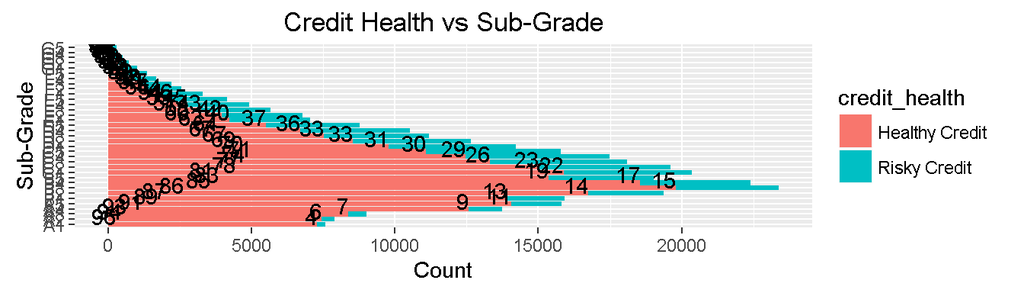

There seems to be a link with sub-grade and the credit health. Percentage keeps increasing as the credit goes down. Credit grade and subgrade needs to be examined as potential factors.

## 5. Loan Status versus Purpose

First, let’s check which reasons are mostly given as the purpose of the loan via using word cloud.

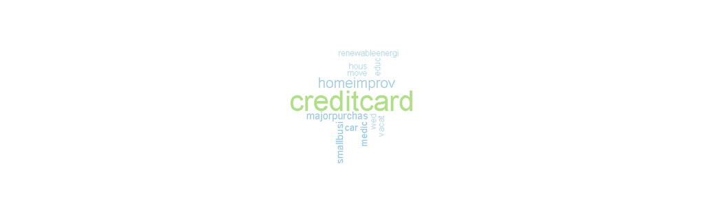

Let’s see also via a bar plot how these reasons look versus credit healthiness.

```
## Source: local data frame [14 x 5]
## Groups: purpose [14]
##
##               purpose credit_health occ_count  total percentage
##                (fctr)        (fctr)     (int)  (int)      (dbl)
## 1                 car  Risky Credit       694   4468   15.53268
## 2         credit_card  Risky Credit     14457  69799   20.71233
## 3  debt_consolidation  Risky Credit     51176 205032   24.96001
## 4         educational  Risky Credit        56    325   17.23077
## 5    home_improvement  Risky Credit      4248  20415   20.80823
## 6               house  Risky Credit       461   2033   22.67585
## 7      major_purchase  Risky Credit      1540   7986   19.28375
## 8             medical  Risky Credit       962   3724   25.83244
## 9              moving  Risky Credit       688   2594   26.52274
## 10              other  Risky Credit      4797  18668   25.69638
## 11   renewable_energy  Risky Credit        75    322   23.29193
## 12     small_business  Risky Credit      1916   5789   33.09725
## 13           vacation  Risky Credit       485   2095   23.15036
## 14            wedding  Risky Credit       279   2106   13.24786
```

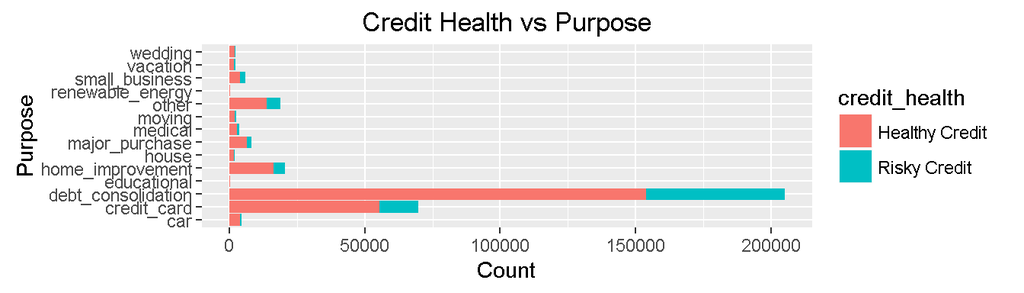

Since there is a bias that most of the loan purposes are due to debt consolidation, it sounds reasonable to see that most of the risky credit is also there. However, it cannot be easily concluded that it is a major contributor to risk credit.

## 6. Loan Status versus Interest Rate

In general, one expects interest rate to be an indicator of credit riskiness. Therefore, the relationship between credit health and interest rate is checked.

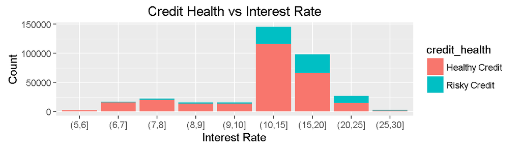

As the interest rate goes up, there is a higher chance of credit failure risk. That is a sound result and it is something expected.

## Wrap-up

It looks like many of the typical thought indicators seem to have a relation with the health of the credit loan. Below given correlation plots also point to the same direction. However all the graphs plato after a certain level. That is why it is necessary to look at the multivariate impacts of the variables.

Below given mapping illustrates which one of the selected variables may have correlation with credit health in detail:

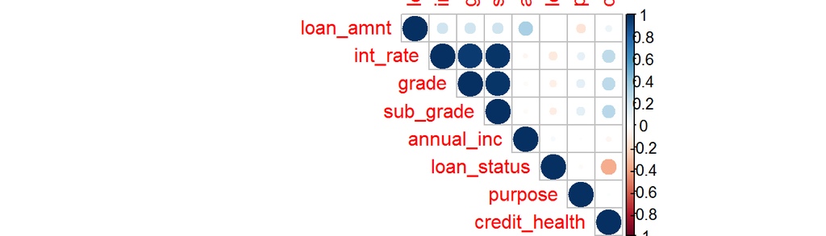

# CONCLUSION of DESCRIPTIVE ANALYSIS

All in all it is useful to look for multivariate effects via using classification models. Single effects of the commonly thought economic indicators for credit health were not succesfull enough to explain the credit healthiness.

For that purpose **Random forest** model is used to classify the loan types and find which variables work together **to give a better indication of loan status**.

# RANDOM FOREST MACHINE LEARNING MODEL

The machine learning algorithm is run via usage of following R model file General_run.R which can be found in Github in the following link https://github.com/mesarikaya/Lending-Club-Customer-Default-or-payment-delay-prediction/blob/master/General_run.R.